# Assignment 4

Divya Singireddy

2024-03-17

## PROBLEM STATEMENT

An equities analyst is studying the pharmaceutical industry and would like your help in exploring and understanding the financial data collected by her firm. Her main objective is to understand the structure of the pharmaceutical industry using some basic financial measures. Financial data gathered on 21 firms in the pharmaceutical industry are available in the file Pharmaceuticals.csv Download Pharmaceuticals.csv. For each firm, the following variables are recorded:

1.Market capitalization (in billions of dollars)

2.Beta

3.Price/earnings ratio

4.Return on equity

5.Return on assets

6.Asset turnover

7.Leverage

8.Estimated revenue growth

9.Net profit margin

10.Median recommendation (across major brokerages)

11.Location of firm’s headquarters

12.Stock exchange on which the firm is listed

Use cluster analysis to explore and analyze the given dataset as follows:

Use only the numerical variables (1 to 9) to cluster the 21 firms. Justify the various choices made in conducting the cluster analysis, such as weights for different variables, the specific clustering algorithm(s) used, the number of clusters formed, and so on. Interpret the clusters with respect to the numerical variables used in forming the clusters. Is there a pattern in the clusters with respect to the numerical variables (10 to 12)? (those not used in forming the clusters) Provide an appropriate name for each cluster using any or all of the variables in the dataset.

## SOLUTION

Using the k-implies grouping approach, I will perform a non-various tiered bunch inspection for this project. The data will be put into consistent categories so that important information may be extracted. Prioritize stacking by stacking the first dataset and any required bundles. This includes information from about twenty-one pharmaceutical companies.

#Installing the libraries using install.packages() and calling the requried libraries

```r
#data manipulation
library(tidyverse)
 # clustering algorithms
library(cluster)
# clustering algorithms & visualization
library(factoextra)
```

```r
library(ggplot2)
library(ISLR)
library(gridExtra)
library(flexclust)
library(dbscan)
#importing the dataset and reading the dataset

PCT_dataset <- read.csv("C:/Users/divya/Downloads/Pharmaceuticals.csv")
head(PCT_dataset)
```

```
##   Symbol                Name Market_Cap Beta PE_Ratio  ROE  ROA Asset_Turnover
## 1    ABT Abbott Laboratories      68.44 0.32     24.7 26.4 11.8            0.7
## 2    AGN      Allergan, Inc.       7.58 0.41     82.5 12.9  5.5            0.9
## 3    AHM        Amersham plc       6.30 0.46     20.7 14.9  7.8            0.9
## 4    AZN     AstraZeneca PLC      67.63 0.52     21.5 27.4 15.4            0.9
## 5    AVE             Aventis      47.16 0.32     20.1 21.8  7.5            0.6
## 6    BAY            Bayer AG      16.90 1.11     27.9  3.9  1.4            0.6
##   Leverage Rev_Growth Net_Profit_Margin Median_Recommendation Location Exchange
## 1     0.42       7.54              16.1          Moderate Buy       US     NYSE
## 2     0.60       9.16               5.5          Moderate Buy   CANADA     NYSE
## 3     0.27       7.05              11.2            Strong Buy       UK     NYSE
## 4     0.00      15.00              18.0         Moderate Sell       UK     NYSE
## 5     0.34      26.81              12.9          Moderate Buy   FRANCE     NYSE
## 6     0.00      -3.17               2.6                  Hold  GERMANY     NYSE
```

## 1. To cluster the 21 enterprises, use just the number variables (1 to 9). Explain the decisions you made when performing the cluster analysis, including the weights assigned to the individual variables, the particular clustering algorithm(s) you chose, the number of clusters you produced, and so on.

```r
#To exclude any potential missing values from the data
PCTdata <- na.omit(PCT_dataset)
#Assembling numerical data to group 21 businesses from columns 1 through 9.
row.names(PCTdata)<- PCTdata[,1]
PH<- PCTdata[, 3:11]
head(PH)
```

```
##     Market_Cap Beta PE_Ratio  ROE  ROA Asset_Turnover Leverage Rev_Growth
## ABT      68.44 0.32     24.7 26.4 11.8            0.7     0.42       7.54
## AGN       7.58 0.41     82.5 12.9  5.5            0.9     0.60       9.16
## AHM       6.30 0.46     20.7 14.9  7.8            0.9     0.27       7.05
## AZN      67.63 0.52     21.5 27.4 15.4            0.9     0.00      15.00
## AVE      47.16 0.32     20.1 21.8  7.5            0.6     0.34      26.81
## BAY      16.90 1.11     27.9  3.9  1.4            0.6     0.00      -3.17
##     Net_Profit_Margin
## ABT              16.1
## AGN               5.5
## AHM              11.2
## AZN              18.0
## AVE              12.9
## BAY               2.6
```

```r
#normalizing the data using Scale function
PH2<- scale(PH)
head(PH2)
```

```
##     Market_Cap        Beta    PE_Ratio         ROE        ROA Asset_Turnover
## ABT  0.1840960 -0.80125356 -0.04671323  0.04009035  0.2416121      0.0000000
## AGN -0.8544181 -0.45070513  3.49706911 -0.85483986 -0.9422871      0.9225312
## AHM -0.8762600 -0.25595600 -0.29195768 -0.72225761 -0.5100700      0.9225312
## AZN  0.1702742 -0.02225704 -0.24290879  0.10638147  0.9181259      0.9225312
## AVE -0.1790256 -0.80125356 -0.32874435 -0.26484883 -0.5664461     -0.4612656
## BAY -0.6953818  2.27578267  0.14948233 -1.45146000 -1.7127612     -0.4612656
##       Leverage Rev_Growth Net_Profit_Margin
## ABT -0.2120979 -0.5277675        0.06168225
## AGN  0.0182843 -0.3811391       -1.55366706
## AHM -0.4040831 -0.5721181       -0.68503583
## AZN -0.7496565  0.1474473        0.35122600
## AVE -0.3144900  1.2163867       -0.42597037
## BAY -0.7496565 -1.4971443       -1.99560225
```

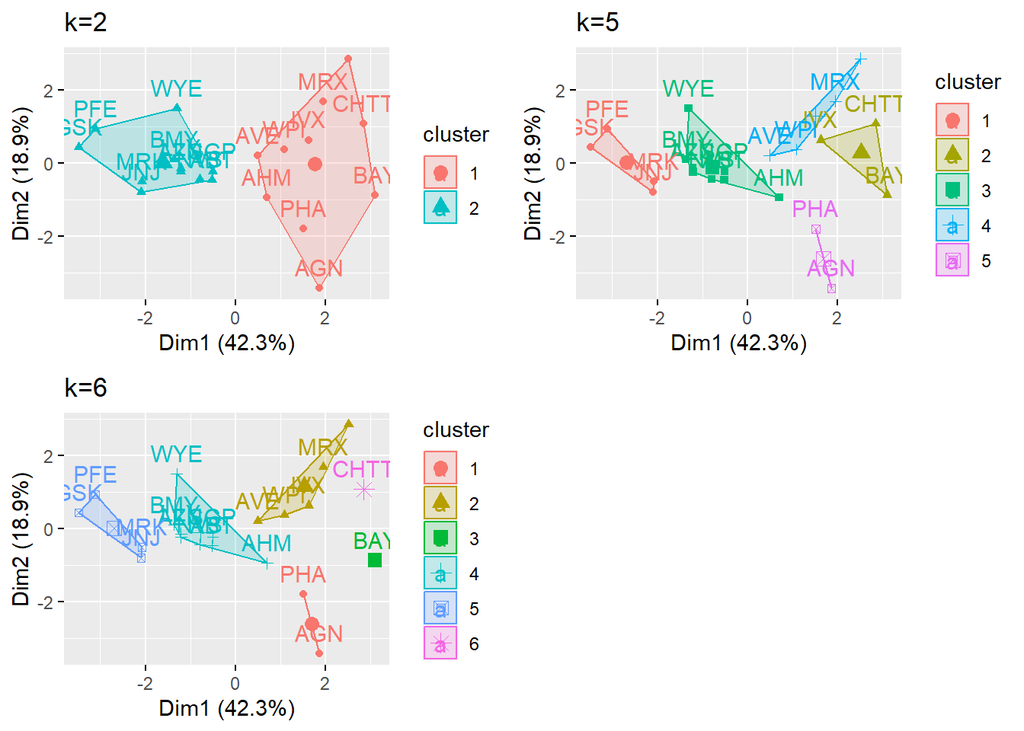

```r
#K-means clustering computation in R for various centres
#Using several K values, compare the variations in the outcomes.

k <- kmeans(PH2, centers = 2, nstart = 30)
k1<- kmeans(PH2, centers = 5, nstart = 30)
k2<- kmeans(PH2, centers = 6, nstart = 30)
p1<-fviz_cluster(k, data = PH2)+ggtitle("k=2")
p2<-fviz_cluster(k1, data = PH2)+ggtitle("k=5")
p3<-fviz_cluster(k2, data = PH2)+ggtitle("k=6")
grid.arrange(p1,p2,p3, nrow = 2)
```

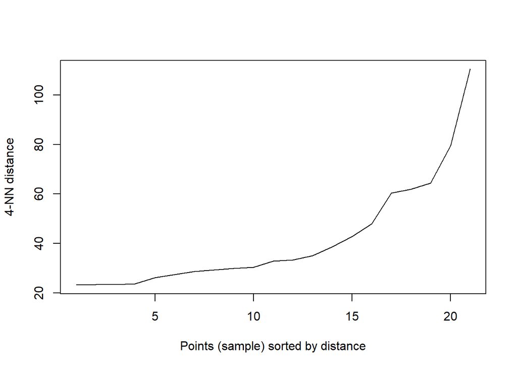

```r
#To determine the optimal radius or eps value.

#Graph to determine the optimal radius value at the minimum points of 4.
dbscan::kNNdistplot(PH, k=4)
```

```r
# DBSCAN Algorithm with minpts = 4 and eps = 30
DBSCAN <- dbscan::dbscan(PH, eps = 30, minPts = 4)

# Output from the groups
print(DBSCAN)
```

```
## DBSCAN clustering for 21 objects.
## Parameters: eps = 30, minPts = 4
## Using euclidean distances and borderpoints = TRUE
## The clustering contains 2 cluster(s) and 6 noise points.
##
## 0 1 2
## 6 8 7
##
## Available fields: cluster, eps, minPts, dist, borderPoints
```

```r
# To determine which point is a member of which cluster
print(DBSCAN$cluster)
```

```
##  [1] 1 0 2 1 1 2 1 2 2 1 0 2 0 2 0 1 0 0 1 2 1
```

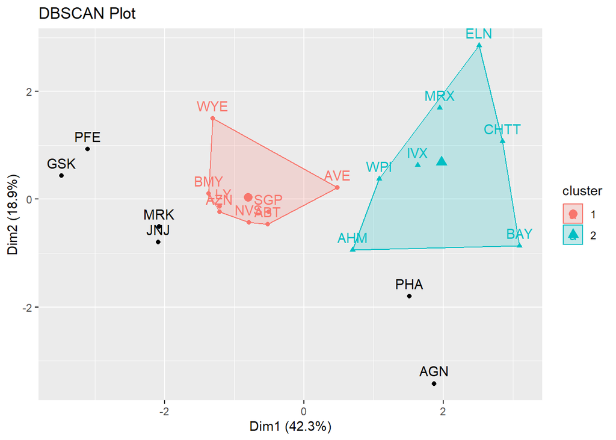

```r
# Visualization of clusters
fviz_cluster(DBSCAN, PH) + ggtitle("DBSCAN Plot")
```

##K-means clustering can provide information on the financial profiles of pharmaceutical companies, and it’s widely used in exploratory data analysis to uncover patterns and groups in the data, which is why I choose it over DBSCAN. DBSCAN can be helpful in exposing groups of enterprises with similar financial features, which can aid in strategic decision-making and investment analysis for datasets with dense areas. It is also easy to understand.The K-means algorithm requires a fixed number of clusters, k. The user can decide how many clusters to construct, which may be useful in some situations. The number of clusters may not be easily determined using DBSCAN or hierarchical clustering.

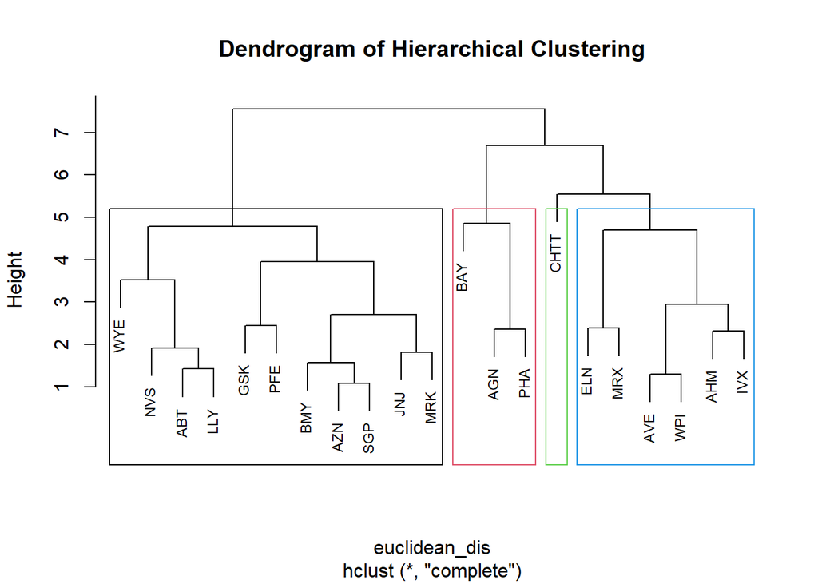

```r
# Hierarchical Clustering

# Determine the data's euclidean distance.
euclidean_dis <- dist(PH2, method = "euclidean")

# Hierarchical Clustering
hierarch_clust <- hclust(euclidean_dis, method = "complete")

# Show the Dendrogram output at height=5.
plot(hierarch_clust, cex = 0.75, main = "Dendrogram of Hierarchical Clustering")
rect.hclust(hierarch_clust, h=5, border = 1:5)
```